# Analysis of onomatopoeias

Bodo

16/11/2020

# 1 Introduction

This analysis will focus on the onomatopoeias, and using the full dataset that’s available as no hand annotation is required.

# 2 Setup

Load packages:

```r
library(tidyverse)
library(tidytext) # for unnest_tokens()
library(brms)
library(wordcloud) # for word cloud
```

Get all file names:

```r
birds <- read_csv('../data/birds_master_file_annotated_12_02_25.csv')
```

# 3 Onomatopoeia and word count analyses

Count onomatopoeias and warblishes:

```r
birds <- mutate(birds,
                onom_count = str_count(voice, '\\".+?\\"'),
                warblish_count = str_count(voice, '\\*.+?\\*'))
```

Count the words and add a count variable:

```r
word_counts <- birds |>
  unnest_tokens(word, voice) |>
  count(unique_id) |>
  rename(word_count = n)
```

Join that back in:

```r
birds <- left_join(birds, word_counts)
```

Plot of onomatopoeia count with word count:

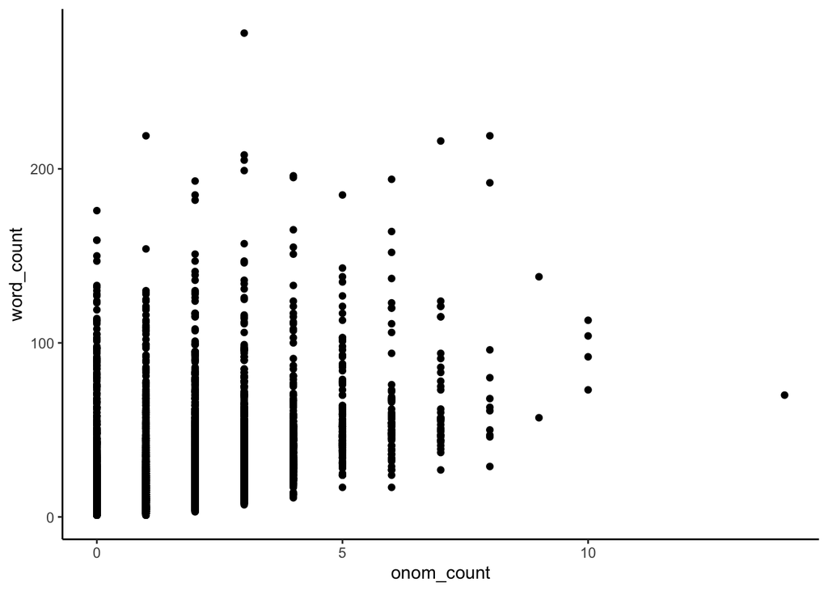

```r
birds |>
  ggplot(aes(x = onom_count, y = word_count)) +
  geom_point() +
  theme_classic()
```

Create a has onomatopoeia / has no onomatopoeia variable and see whether we can make more sense of that:

```r
birds <- mutate(birds,
                has_onom = if_else(onom_count > 0, 'has onomatopoeia', 'no onomatopoeia'))
```

Check word counts for those:

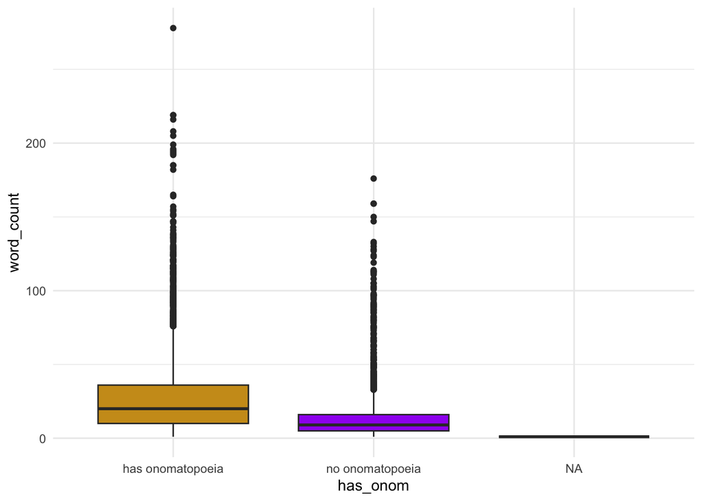

```r
birds |>
  ggplot(aes(x = has_onom, y = word_count, fill = has_onom)) +
  scale_fill_manual(values = c('goldenrod3', 'purple', 'darkgrey')) +
  geom_boxplot() +
  theme_minimal() +
  theme(legend.position = 'none')
```

So, if there is an onomatopoeia it’s also a longer text. I guess this makes sense if what’s happening here is that some fieldguides just generally have more info, and they’re also going to contain more onomatopoeias.

# 4 Individualizing onomatopoeia patterns

## 4.1 Extract onomatopoeia

Extract onomatopoeias and warblish:

```r
# Extract onomatopoeias:

birds$onoms <- sapply(str_extract_all(birds$voice, '\\".+?\\"'),
                      function(x) str_c(x, collapse = '_'))
```

Create an onomatopoeia-free version of the text to see if we can compare things to the typographically unmarked ones:

```r
birds <- mutate(birds,
                voice_reduced = str_replace_all(voice_reduced, '\\".+?\\"', ''),
                voice_reduced = str_replace_all(voice_reduced, '\\*.+?\\*', ''))
```

## 4.2 Preceding character

Get the directly preceding character:

```r
birds$preceding_char <- sapply(
  str_match_all(birds$voice, '(\\S)\\s*\\".+?\\"'),
  function(x) str_c(x[,2], collapse = '_')
  )
```

Check if there’s any where the separator counts don’t match:

```r
birds |>
  filter(!(str_count(onoms, '_') == str_count(preceding_char, '_'))) |>
  select(onoms, preceding_char, voice)
```

```
## # A tibble: 47 × 3
##    onoms                                                    preceding_char voice
##    <chr>                                                    <chr>          <chr>
##  1 "\"Tchink, tchink, tchink\"_\"tchook\""                  k              "\"T…
##  2 "\"zip\"_\"churt\"_\"chim\"_\"cheedle cheedle chee?\"_\… e_,_,_y        "Bel…
##  3 "\"woo-hoo\"_\"hoo-hoo-hoo\""                            o              "\"w…
##  4 "\"Chicky-whew\"_\"chee-lick\""                          w              "\"C…
##  5 "\"too-li\"_\"coo-eep\""                                 i              "\"t…
##  6 "\"Tserp-tserp\"_\"pi-pi-pi...\""                        p              "\"T…
##  7 "\"chew-ich\"_\"aach\""                                  h              "\"c…
##  8 "\"Churrr, churrr, churrr\"_\"chirriree\"_\"keereereek\… r_e            "\"C…
##  9 "\"tac tac\"_\"cherr\""                                  c              "\"t…
## 10 "\"Tchack tchak\"_\"terr terr\"_\"see-ip\""              k_r            "\"T…
## # ℹ 37 more rows
```

This is whenever the onomatopoeia is first. So, let’s append an empty space before that with the separator (these are all multi-onomatopoeia entries):

```r
fixed_preceding_chars <- birds |>
  filter(!(str_count(onoms, '_') == str_count(preceding_char, '_'))) |>
  select(onoms, preceding_char, voice) |>
  mutate(preceding_char = str_c(' _', preceding_char)) |>
  pull(preceding_char)
```

And add that back into the data:

```r
# Get offending rows:

rows_to_fix <- !(str_count(birds$onoms, '_') == str_count(birds$preceding_char, '_'))
rows_to_fix <- which(rows_to_fix)

# Re-add the fixed strings:

birds[rows_to_fix, ]$preceding_char <- fixed_preceding_chars
```

Check now that it’s the correct number each time:

```r
birds |>
  filter(!(str_count(onoms, '_') == str_count(preceding_char, '_')))
```

```
## # A tibble: 0 × 31
## # ℹ 31 variables: unique_id <chr>, fieldguide <chr>, english_common <chr>,
## #   latin_species <chr>, length <chr>, order <chr>, family <chr>,
## #   family_english <chr>, voice <chr>, warblish <chr>, usable <chr>,
## #   voice_reduced <chr>, non_vocalization <chr>, distance_amplitude <chr>,
## #   namesake <chr>, qualifies_as_song <lgl>, mimicry <chr>, comparison <chr>,
## #   comparison_type <chr>, comparison_expression <chr>, comparand <chr>,
## #   comp_construction <chr>, comp_dimension <chr>, …
```

Woohoo, it is!

## 4.3 Following character

Let’s get the last character now:

```r
birds$following_char <- sapply(
  str_match_all(birds$voice, '\\".+?\\"\\s*(\\S)'),
  function(x) str_c(x[,2], collapse = '_')
)
```

Check when they don’t align:

```r
birds |>
  filter(!(str_count(onoms, '_') == str_count(following_char, '_'))) |>
  pull(voice)
```

```
## [1] "Flight call a coarse \"grrrt\"; lower single note \"dirp\" like Western Meadowlark; also a coarse, grating \"ji ji ji ji ji\"; In courtship a low, soft moan very similar to distant cow mooing; Flight song a rapidly repeated, wild, harsh whistle \"we we we we we...\""
## [2] "Sharp \"scaap\" when flushed and a musical \"chippa-chippa-chippa\""
## [3] "Bell's Vireo has numerous calls. Most often heard is a fast, nasal, scolding alarm call, which sounds wrenlike. Other calls associated with conflict or contact include \"zip\", \"churt\", \"chim\", and a high, piercing squeal. The primary song is a hurried, scratchy \"cheedle cheedle chee?\"…
## [4] "loud, ringing calls that reverberate from rock walls of gorges. Many variations, often beginning with high, clear, drawn out, rising whistles, quickly followed by abrupt, rich, mellow, at times bubbling notes. Among these: \"pieeer-pieeer, chokka-chok-chok\"; \"wheeeit-wheeeit, quorr-quorr-q…
## [5] "A harsh \"jeet\" is the most commonly heard call, usually from flying or feeding birds. They make various distress, alarm, and contact calls mostly on the breeding grounds. Displaying males sing a brief song that begins with a high, thin, rising \"te-e-e-e-e\" \"tweer-tweer-tweer\" and close…
```

Ok, essentially just two offending patterns, which are either the onomatopoeia is last, as in 1 and 2, or there’s just a space and then the next onomatopoeia already starts, with nothing intervening.

Get these offending rows:

```r
rows_to_fix <- !(str_count(birds$onoms, '_') == str_count(birds$following_char, '_'))
rows_to_fix <- which(rows_to_fix)
```

THen we’ll fix these by hand - it’s only a couple cases anyway:

```r
birds[rows_to_fix, ]$following_char <- c(';_l_;_ ',
                                         'w_ ',
                                         ',_,_,_ _-',
                                         ';_;_ ',
                                         'i_ _a')
```

## 4.4 Extract preceding word

Extract preceding word:

```r
birds$preceding_word <- sapply(
  str_match_all(birds$voice, '(?:(\\b\\S+)\\s+)?\\".+?\\"'),
  function(x) str_c(ifelse(is.na(x[,2]), "", x[,2]), collapse = '_')
)
```

Now, check if there’s any mismatching numbers:

```r
filter(birds,
       !(str_count(preceding_word, '_') == str_count(onoms, '_')))
```

```
## # A tibble: 0 × 33
## # ℹ 33 variables: unique_id <chr>, fieldguide <chr>, english_common <chr>,
## #   latin_species <chr>, length <chr>, order <chr>, family <chr>,
## #   family_english <chr>, voice <chr>, warblish <chr>, usable <chr>,
## #   voice_reduced <chr>, non_vocalization <chr>, distance_amplitude <chr>,
## #   namesake <chr>, qualifies_as_song <lgl>, mimicry <chr>, comparison <chr>,
## #   comparison_type <chr>, comparison_expression <chr>, comparand <chr>,
## #   comp_construction <chr>, comp_dimension <chr>, …
```

None, perfect.

```r
birds$following_word <- sapply(
  str_match_all(birds$voice, '\\".+?\\"\\s+(\\b\\S+)?'),
  function(x) str_c(ifelse(is.na(x[,2]), "", x[,2]), collapse = '_')
)
```

Check that it’s the same number:

```r
filter(birds,
       !(str_count(following_word, '_') == str_count(onoms, '_')))
```

```
## # A tibble: 2,055 × 34
##    unique_id fieldguide         english_common latin_species length order family
##    <chr>     <chr>              <chr>          <chr>         <chr>  <chr> <chr>
##  1 id_5423   sibley_birds       Roseate Spoon… Platalea aja… 32     Pele… Thres…
##  2 id_3911   national_geograph… Golden-fronte… Melanerpes a… 25cm   Pici… Picid…
##  3 id_356    allabout_birds     McCown's Long… Rhynchophane… 15     Pass… Calca…
##  4 id_5721   sibley_birds       Peregrine Fal… Falco peregr… 16     Falc… Falco…
##  5 id_4261   national_geograph… Eastern Towhee Pipilo eryth… 19cm   Pass… Passe…
##  6 id_4697   peterson_chalif_m… Dusky Antbird  Cercomacroid… 5.25-… <NA>  <NA>
##  7 id_997    bruun_hamlyn_guide Long-tailed t… Aegithalos c… 14     Pass… Aegit…
##  8 id_2015   felix_hisek_birds  Ringed Plover  Charadrius h… 19     Char… Chara…
##  9 id_4717   peterson_chalif_m… Vermilion Fly… Pyrocephalus… 5-6in  Pass… Tyran…
## 10 id_5637   sibley_birds       Greater Roadr… Geococcyx ca… 23     <NA>  <NA>
## # ℹ 2,045 more rows
## # ℹ 27 more variables: family_english <chr>, voice <chr>, warblish <chr>,
## #   usable <chr>, voice_reduced <chr>, non_vocalization <chr>,
## #   distance_amplitude <chr>, namesake <chr>, qualifies_as_song <lgl>,
## #   mimicry <chr>, comparison <chr>, comparison_type <chr>,
## #   comparison_expression <chr>, comparand <chr>, comp_construction <chr>,
## #   comp_dimension <chr>, duplicated_comparison <chr>, comments <chr>, …
```

This doesn’t work yet. **Note**: Fix later.

## 4.5 Put onomatopoeias into long format

Get only the rows we need:

```r
onoms_only <- birds |>
  select(unique_id, voice, onoms, preceding_char, preceding_word, following_char)
```

Make it into long format:

```r
onoms_long <- onoms_only |>
  separate_longer_delim(c(onoms, preceding_char, preceding_word, following_char),
                        delim = '_')

# Change order:

onoms_long <- onoms_long |>
  select(unique_id, voice, preceding_char, following_char, preceding_word, onoms) |>
  rename(onomatopoeia = onoms)

# Fill empty rows with NAs:

onoms_long <- mutate(onoms_long,
                     preceding_char = if_else(preceding_char == '', NA, preceding_char),
                     following_char = if_else(following_char == '', NA, following_char),
                     preceding_word = if_else(preceding_word == '', NA, preceding_word),
                     onomatopoeia = if_else(onomatopoeia == '', NA, onomatopoeia))
```

## 4.6 Get rid of quotes

Now let’s get rid of the quotes:

```r
onoms_long <- mutate(onoms_long,
                     onomatopoeia = str_replace_all(onomatopoeia, '\"', ''))
```

## 4.7 Extract for hand annotation

For hand-annotation, we’ll create two extra columns:

```r
# onoms_long$phono_legal <- NA
# onoms_long$complex_onset <- NA
```

Write it to file outside of R:

```r
# write_csv(onoms_long,
#           '../data/onomatopoeias_all_extracted.csv')
```

# 5 Syntactic explorations

## 5.1 Onomatopoeia length and sentence position

Calculate the length of the onomatopoeias:

```r
onoms_long <- mutate(onoms_long,
                     length = str_count(onomatopoeia, '.'))
```

Check what precedes:

```r
onoms_long |>
  count(preceding_char, sort = TRUE) |>
  print(n = Inf)
```

```
## # A tibble: 41 × 2
##    preceding_char     n
##    <chr>          <int>
##  1 <NA>            2224
##  2 "g"             1373
##  3 "d"             1246
##  4 "r"             1015
##  5 "e"              791
##  6 ","              587
##  7 "l"              563
##  8 "t"              513
##  9 "p"              451
## 10 "y"              417
## 11 "s"              412
## 12 "h"              344
```

[output cut: 29 more lines]

Any letter or number is within the sentence:

```r
onoms_long <- onoms_long |>
  mutate(pre_isolation = if_else(preceding_char %in% letters,
                                 'in sentence', preceding_char),
         pre_isolation = if_else(pre_isolation %in% LETTERS,
                                 'in sentence', pre_isolation),
         pre_isolation = if_else(pre_isolation %in% as.character(0:9),
                                 'in sentence', pre_isolation),
         pre_isolation = if_else(pre_isolation == ' ',
                                 'starts sentence', pre_isolation),
         pre_isolation = if_else(pre_isolation == '.',
                                 'starts sentence', pre_isolation),
         pre_isolation = if_else(pre_isolation == '(',
                                 'in brackets', pre_isolation),
         pre_isolation = if_else(pre_isolation == '-',
                                 'after hyphen', pre_isolation),
         pre_isolation = if_else(pre_isolation == ';',
                                 'after semicolon', pre_isolation),
         pre_isolation = if_else(pre_isolation == ':',
                                 'after colon', pre_isolation),
         pre_isolation = if_else(pre_isolation == ',',
                                 'after comma', pre_isolation),
         pre_isolation = if_else(pre_isolation %in% c("=", "'", ")"),
                                 NA, pre_isolation))
```

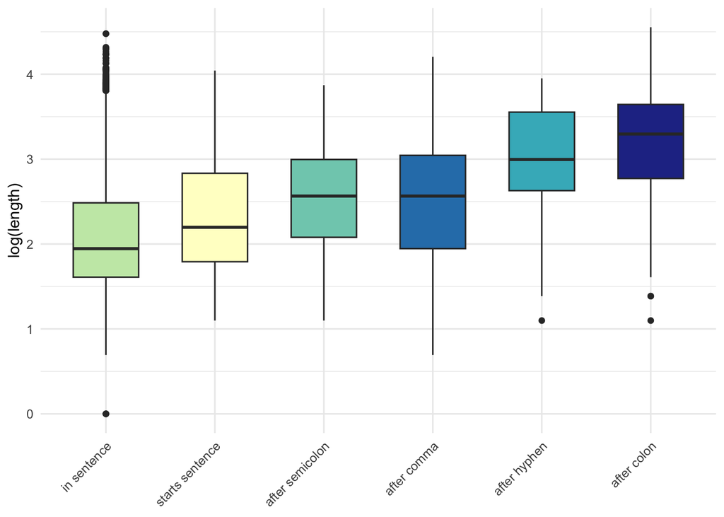

```r
onoms_long |>
  filter(!is.na(pre_isolation)) |>
  filter(pre_isolation != 'in brackets') |>
  ggplot(aes(x = reorder(pre_isolation, length), y = log(length),
             fill = pre_isolation)) +
  scale_fill_brewer(direction = -1,
                    palette = 'YlGnBu') +
  geom_boxplot(width = 0.6) +
  xlab(NULL) +
  theme_minimal() +
  theme(axis.text.x = element_text(angle = 45, hjust = 1),
        legend.position = 'none')
```

```r
# Save:

ggsave('../figures/onomatopoeia_length_by_sentence.pdf',
       width = 4.5, height = 4)
```

## 5.2 Whether it’s a word and sentence position

Get the CMU data:

```r
CMU <- readLines('../data/CMU_dict-0.7b.txt')
CMU <- CMU[-c(1:126)] # only metadata
CMU <- str_split(CMU, pattern = ' +')
words <- sapply(CMU, FUN = function(x) x[1])
words <- str_to_lower(words)
```

Check which of the onomatopoeias are also a word:

```r
onoms_long <- mutate(onoms_long,
                     is_also_word = if_else(onomatopoeia %in% words,
                                            'is also a word', 'is not a word'))
```

How many of these?

```r
onoms_long |>
  count(is_also_word)
```

```
## # A tibble: 2 × 2
##   is_also_word       n
##   <chr>          <int>
## 1 is also a word  1119
## 2 is not a word  10237
```

Cool, let’s see if any patterns emerge:

```r
onoms_long |>
  filter(!is.na(pre_isolation)) |>
  count(pre_isolation, is_also_word) |>
  group_by(pre_isolation) |>
  mutate(p = n / sum(n))
```

```
## # A tibble: 13 × 4
## # Groups:   pre_isolation [7]
##    pre_isolation   is_also_word       n      p
##    <chr>           <chr>          <int>  <dbl>
##  1 after colon     is also a word     3 0.0123
##  2 after colon     is not a word    241 0.988
##  3 after comma     is also a word    24 0.0409
##  4 after comma     is not a word    563 0.959
##  5 after hyphen    is not a word     19 1
##  6 after semicolon is also a word     2 0.0260
##  7 after semicolon is not a word     75 0.974
##  8 in brackets     is also a word     5 0.385
##  9 in brackets     is not a word      8 0.615
## 10 in sentence     is also a word  1077 0.133
## 11 in sentence     is not a word   7035 0.867
## 12 starts sentence is also a word     5 0.0685
## 13 starts sentence is not a word     68 0.932
```

Make a plot of this:

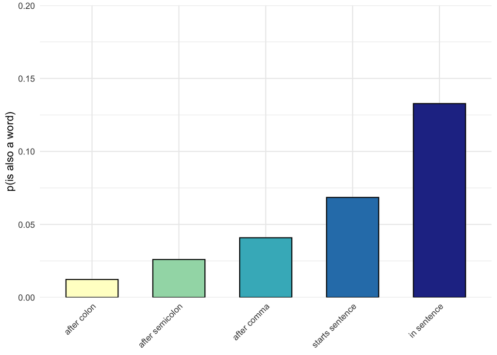

```r
onoms_long |>
  filter(!is.na(pre_isolation)) |>
  filter(pre_isolation != 'in brackets') |>
  count(pre_isolation, is_also_word) |>
  group_by(pre_isolation) |>
  mutate(p = n / sum(n)) |>
  filter(is_also_word == 'is also a word') |>
  ggplot(aes(x = reorder(pre_isolation, p), y = p,
             fill = reorder(pre_isolation, p))) +
  geom_col(col = 'black',
           width = 0.6) +
  scale_fill_brewer(direction = +1,
                    palette = 'YlGnBu') +
  scale_y_continuous(expand = c(0, 0),
                     limits = c(0, 0.2)) +
  xlab(NULL) +
  ylab('p(is also a word)') +
  theme_minimal() +
  theme(legend.position = 'none',
        axis.text.x = element_text(angle = 45, hjust = 1))
```

```r
ggsave('../figures/syntactic_isolation_and_dictionary_word_match.pdf',
       width = 4.5, height = 3.5)
```

## 5.3 Whether it has repeated consonants

Count the repeated consonants:

```r
onoms_long <- onoms_long |>
  mutate(repeated_consonants = str_count(onomatopoeia, "(?i)([b-df-hj-np-tv-z])\\1+"))
```

Cool. Let’s make a variable out of this that just codes for whether it has repeated consonants or not:

```r
onoms_long <- onoms_long |>
  mutate(has_repeated = if_else(repeated_consonants > 1, 'has letter replication', 'no letter replication'))
```

Check this as a function of syntax:

```r
onoms_long |>
  filter(!is.na(pre_isolation)) |>
  count(pre_isolation, has_repeated) |>
  group_by(pre_isolation) |>
  mutate(p = n / sum(n))
```

```
## # A tibble: 13 × 4
## # Groups:   pre_isolation [7]
##    pre_isolation   has_repeated               n      p
##    <chr>           <chr>                  <int>  <dbl>
##  1 after colon     has letter replication    40 0.164
##  2 after colon     no letter replication    204 0.836
##  3 after comma     has letter replication    41 0.0698
##  4 after comma     no letter replication    546 0.930
##  5 after hyphen    has letter replication     4 0.211
##  6 after hyphen    no letter replication     15 0.789
##  7 after semicolon has letter replication    11 0.143
##  8 after semicolon no letter replication     66 0.857
##  9 in brackets     no letter replication     13 1
## 10 in sentence     has letter replication   343 0.0423
## 11 in sentence     no letter replication   7769 0.958
## 12 starts sentence has letter replication     2 0.0274
## 13 starts sentence no letter replication     71 0.973
```

Make a plot of this:

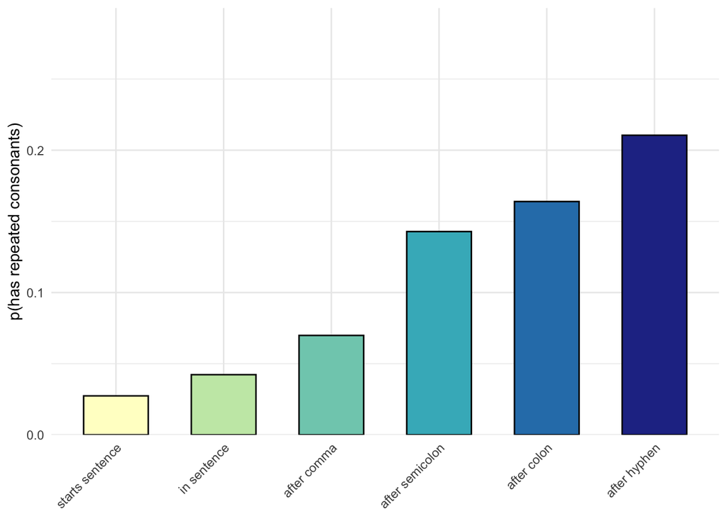

```r
onoms_long |>
  filter(!is.na(pre_isolation)) |>
  count(pre_isolation, has_repeated) |>
  group_by(pre_isolation) |>
  mutate(p = n / sum(n)) |>
  filter(has_repeated == 'has letter replication') |>
  ggplot(aes(x = reorder(pre_isolation, p), y = p,
             fill = reorder(pre_isolation, p))) +
  geom_col(col = 'black',
           width = 0.6) +
  scale_fill_brewer(direction = +1,
                    palette = 'YlGnBu') +
  scale_y_continuous(expand = c(0, 0),
                     limits = c(0, 0.3)) +
  xlab(NULL) +
  ylab('p(has repeated consonants)') +
  theme_minimal() +
  theme(legend.position = 'none',
        axis.text.x = element_text(angle = 45, hjust = 1))
```

```r
# Save:

ggsave('../figures/syntactic_isolation_and_letter_replication.pdf',
       width = 4.5, height = 3.5)
```

Make a simplified plot:

```r
# Simplified syntactic isolation variable:

onoms_long <- mutate(onoms_long,
                     syntax_red = if_else(pre_isolation %in% c('after colon',
                                                               'after semicolon'),
                                          'after juncture', NA),
                     syntax_red = if_else(pre_isolation %in% c('starts sentence',
                                                               'in sentence'),
                                          'in sentence', syntax_red))

# Check:

onoms_long |>
  count(syntax_red) |>
  mutate(p = n / sum(n))
```

```
## # A tibble: 3 × 3
##   syntax_red         n      p
##   <chr>          <int>  <dbl>
## 1 after juncture   321 0.0283
## 2 in sentence     8185 0.721
## 3 <NA>            2850 0.251
```

```r
# Check with respect to letter replication:

onoms_long |>
  filter(!is.na(syntax_red)) |>
  count(syntax_red, has_repeated) |>
  group_by(syntax_red) |>
  mutate(p = n / sum(n))
```

```
## # A tibble: 4 × 4
## # Groups:   syntax_red [2]
##   syntax_red     has_repeated               n      p
##   <chr>          <chr>                  <int>  <dbl>
## 1 after juncture has letter replication    51 0.159
## 2 after juncture no letter replication    270 0.841
## 3 in sentence    has letter replication   345 0.0422
## 4 in sentence    no letter replication   7840 0.958
```

Make a plot of this:

[figure not shown]

```r
onoms_long |>
  filter(!is.na(syntax_red)) |>
  count(syntax_red, has_repeated) |>
  group_by(syntax_red) |>
  mutate(p = n / sum(n)) |>
  filter(has_repeated == 'has letter replication') |>
  ggplot(aes(x = reorder(syntax_red, p), y = p,
             fill = syntax_red)) +
  geom_col(
    # col = 'black',
    col = 'white',
    width = 0.4,
    alpha = 0) +
  scale_fill_manual(values = c('#68349a', 'grey')) +
  scale_y_continuous(expand = c(0, 0),
                     limits = c(0, 0.3),
                     breaks = seq(0, 0.3, 0.1)) +
  xlab(NULL) +
  ylab('p(has repeated consonants)') +
  theme_classic() +
  theme(legend.position = 'none',
        axis.text.x = element_text(angle = 0, hjust = 0.5),
        # axis.title.y = element_text(margin = margin(r = 15)),
        axis.title.y = element_blank(),
        axis.text.y = element_blank(),
        axis.line.y = element_blank(),
        axis.ticks.y = element_blank()
        )
```

```r
# Save:

ggsave('../figures/syntactic_isolation_and_letter_replication.pdf',
       width = 2.5, height = 3.5)
```

# 6 Frequency of onomatopoeias

Compute frequency of onomatopoeias:

```r
# Count:

onom_freq <- onoms_long |>
  count(onomatopoeia, sort = TRUE) |>
  filter(!is.na(onomatopoeia))

# Show:

onom_freq
```

```
## # A tibble: 6,916 × 2
##    onomatopoeia     n
##    <chr>        <int>
##  1 chip            75
##  2 tsip            44
##  3 whit            32
##  4 pit             25
##  5 chuck           24
##  6 chirrup         23
##  7 churr           23
##  8 seep            23
##  9 tsee            23
## 10 pik             22
## # ℹ 6,906 more rows
```

Need to fix these:

```r
 # " and "                                                                                          2
 # 2 " as the strongest part. Also has various harsh scoldings: "                                     1
 # 3 " https://ebird.org/news/crossbills-of-north-america-species-and-red-crossbill-call-types/ "     1
 # 4 " very similar to Elf Owl; whining, soft whistle "                                               1
 # 5 ","                                                                                              1
 # 6 ", "
```

## 6.1 Frequency and typographic marking

See whether these also occur in the typographically unmarked positions. For this we can simply collapse the entire `voice_reduced` column into a text and then just grep out of it.

To make sure that we don’t match parts of words, we’ll add spaces around:

```r
all_text <- str_c(filter(birds, !is.na(voice_reduced))$voice_reduced, collapse = ' ')

# Append a word start and word finish:

onom_freq <- mutate(onom_freq,
                    onomatopoeia = str_c(' ', onomatopoeia, ' '))

# Empty column:

onom_freq$unmarked_freq <- 0

# Loop through and add count:

for (i in 1:nrow(onom_freq)) {
  onom_freq[i, ]$unmarked_freq <- onom_freq[i, ]$unmarked_freq +
    str_count(all_text, onom_freq[i, ]$onomatopoeia)

  if (i %% 1000 == 0) {
    cat(str_c("hello outside-loop world, I'm iteration ", i, '\n'))
  }
}

# Save:

save(onom_freq, file = '../models/onom_freq.RData')
```

Load:

```r
load('../models/onom_freq.RData')
```

Check:

```r
onom_freq
```

[output not shown]

Create a “has typographically unmarked version”:

```r
onom_freq <- mutate(onom_freq,
                    has_unmarked = if_else(unmarked_freq > 0, 'occurs typographically unmarked', 'no unmarked'))
```

Get rid of trailing spaces again, which we only embedded to ensure matching within the sentence.

```r
onom_freq <- mutate(onom_freq,
                    onomatopoeia = str_trim(onomatopoeia))
```

Now we can get rid of those onomatopoeias that have spaces or hyphens in them. These are multisyllabic and it would be unfair / biasing towards what I want to show to keep in them analysis since they’re never going to occur typographically unmarked again anyway, being essentially full phrases.

So we should restrict things to the monosyllabic stuff.

```r
onom_freq_red <- filter(onom_freq,
                        !str_detect(onomatopoeia, ",|-| |'|\\."))

# How many are left?

onom_freq_red
```

```
## # A tibble: 2,586 × 4
##    onomatopoeia     n unmarked_freq has_unmarked
##    <chr>        <int>         <dbl> <chr>
##  1 chip            75            68 occurs typographically unmarked
##  2 tsip            44             0 no unmarked
##  3 whit            32             0 no unmarked
##  4 pit             25             0 no unmarked
##  5 chuck           24             1 occurs typographically unmarked
##  6 chirrup         23             4 occurs typographically unmarked
##  7 churr           23             0 no unmarked
##  8 seep            23             0 no unmarked
##  9 tsee            23             0 no unmarked
## 10 pik             22             0 no unmarked
## # ℹ 2,576 more rows
```

Model whether it occurs unmarked as a function of its frequency in the marked version:

```r
onom_freq_red <- mutate(onom_freq_red,
                        has_unmarked = factor(has_unmarked, levels = c('no unmarked', 'occurs typographically unmarked')))

# Fit logistic regression model:

unmarked_mdl <- brm(has_unmarked ~ 1 + log(n),
                    data = onom_freq_red,
                    family = bernoulli,

                    # MCMC settings:

                    chains = 4, iter = 4000, warmup = 2000,
                    cores = 4, init = 0)

# Save:

save(unmarked_mdl, file = '../models/unmarked_mdl.RData')
```

Load:

```r
load('../models/unmarked_mdl.RData')
```

Check model:

```r
unmarked_mdl
```

```
##  Family: bernoulli
##   Links: mu = logit
## Formula: has_unmarked ~ 1 + log(n)
##    Data: onom_freq_red (Number of observations: 2586)
##   Draws: 4 chains, each with iter = 4000; warmup = 2000; thin = 1;
##          total post-warmup draws = 8000
##
## Regression Coefficients:
##           Estimate Est.Error l-95% CI u-95% CI Rhat Bulk_ESS Tail_ESS
## Intercept    -4.00      0.15    -4.31    -3.72 1.00     3667     4090
## logn          0.95      0.12     0.71     1.19 1.00     3841     4467
##
## Draws were sampled using sampling(NUTS). For each parameter, Bulk_ESS
## and Tail_ESS are effective sample size measures, and Rhat is the potential
## scale reduction factor on split chains (at convergence, Rhat = 1).
```

Make a plot of this:

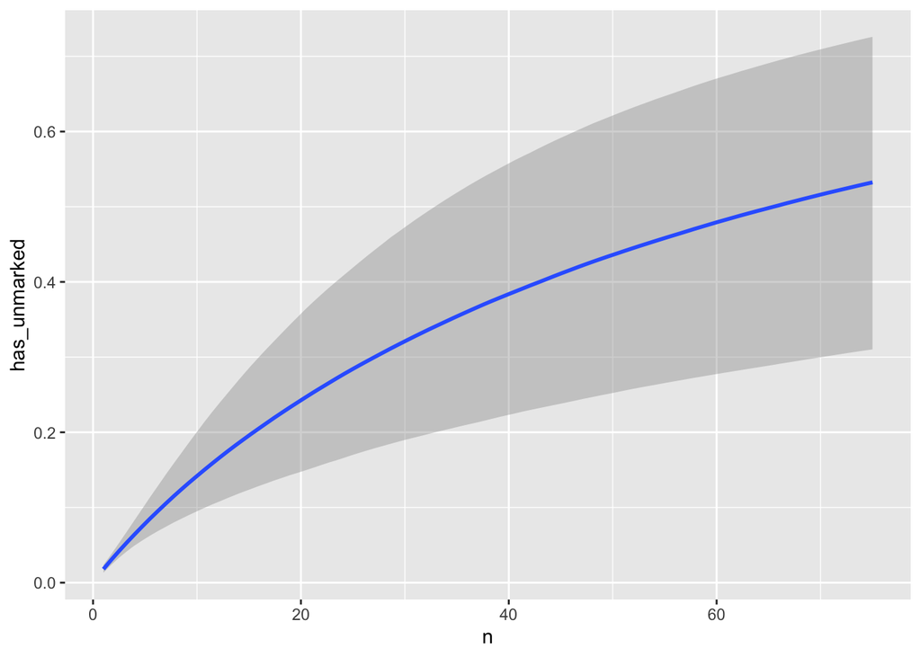

```r
# Show:

conditional_effects(unmarked_mdl)
```

```r
# Save:

ggsave('../figures/probability_of_typographically_unmarked.pdf',
       width = 5, height = 3.5)
```

Extract image data from `conditional_effects()` output for hand-tweaked ggplot:

```r
this_plot_df <- conditional_effects(unmarked_mdl)[[1]]
```

Make a custom ggplot out of this, first without the graph itself:

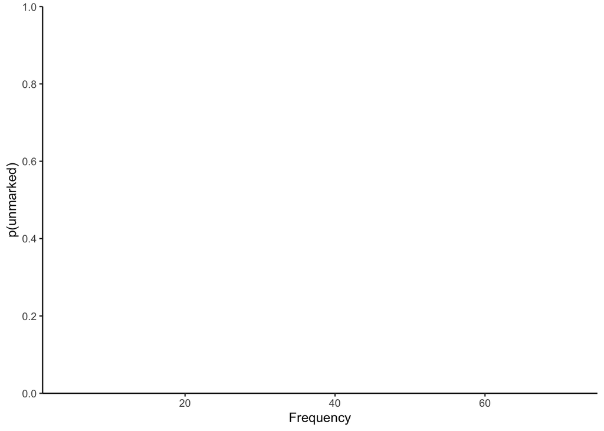

```r
this_plot_df |>
  ggplot(aes(x = n, y = estimate__)) +
  geom_ribbon(mapping = aes(ymin = lower__, ymax = upper__),
              fill = '#68349a', alpha = 0) +
  geom_line(size = 1.5, col = '#68349a', alpha = 0) +
  xlab('Frequency') +
  ylab('p(unmarked)') +
  scale_x_continuous(expand = c(0, 0)) +
  scale_y_continuous(limits = c(0, 1),
                     expand = c(0, 0),
                     breaks = seq(0, 1, 0.2)) +
  theme_classic()
```

```r
# Save:

ggsave('../figures/probability_of_typographically_unmarked.pdf',
       width = 6, height = 3.5)
```

Then with the graph:

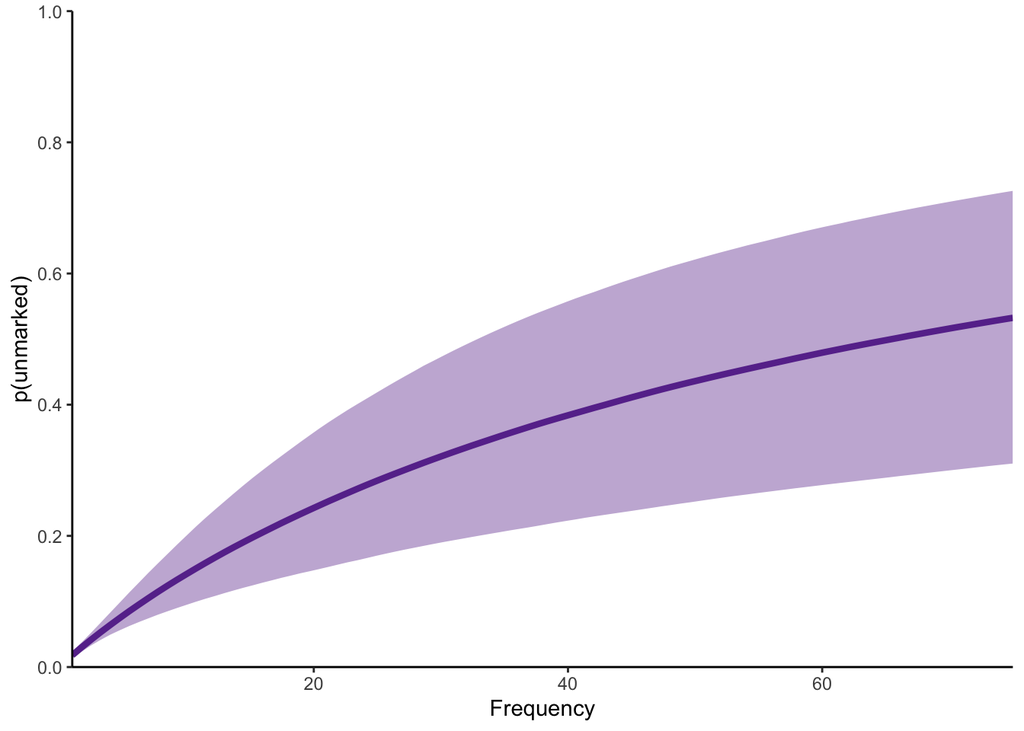

```r
this_plot_df |>
  ggplot(aes(x = n, y = estimate__)) +
  geom_ribbon(mapping = aes(ymin = lower__, ymax = upper__),
              fill = '#68349a', alpha = 0.4) +
  geom_line(size = 1.5, col = '#68349a') +
  xlab('Frequency') +
  ylab('p(unmarked)') +
  scale_x_continuous(expand = c(0, 0)) +
  scale_y_continuous(limits = c(0, 1),
                     expand = c(0, 0),
                     breaks = seq(0, 1, 0.2)) +
  theme_classic()
```

```r
# Save:

ggsave('../figures/probability_of_typographically_unmarked.pdf',
       width = 6, height = 3.5)
```

## 6.2 Frequency and sentence position

See whether more frequent ones also occur in more or less isolated positions. To make some sense of this, we’ll simplify lump the separated ones (after comma, semicolon, and colon) together, as well as all the within-sentence ones, for which we’ll exclude the ones that start the sentence for now as we haven’t checked yet whether a comma or dot follows.

```r
# Vectors for matching:

isolated <- c('after colon', 'after comma', 'after hyphen',
              'after semicolon')
collapse <- c('in brackets', 'starts sentence')

# Match and create new variable pre_iso_red:

onoms_long <- mutate(onoms_long,
                     pre_iso_red = if_else(pre_isolation %in% collapse, NA, pre_isolation),
                     pre_iso_red = if_else(pre_iso_red %in% isolated, 'isolated', pre_iso_red))
```

Count by onomatopoeia and this new variable, after excluding `NA`s:

```r
onoms_long |>
  filter(!is.na(pre_iso_red)) |>
  count(onomatopoeia, pre_iso_red, sort = TRUE) |>
  group_by(onomatopoeia) |>
  mutate(p = n / sum(n)) |>
  slice_tail(n = 100) |>
  print(n = Inf)
```

```
## # A tibble: 6,881 × 4
## # Groups:   onomatopoeia [6,782]
##      onomatopoeia                                       pre_iso_red     n      p
##      <chr>                                              <chr>       <int>  <dbl>
##    1 " and "                                            in sentence     2 1
##    2 " as the strongest part. Also has various harsh s… in sentence     1 1
##    3 " very similar to Elf Owl; whining, soft whistle " in sentence     1 1
##    4 ","                                                in sentence     1 1
##    5 ", "                                               in sentence     3 1
##    6 ", always with the "                               in sentence     1 1
##    7 "-a-chuk"                                          in sentence     1 1
##    8 "-a-kak"                                           isolated        1 1
##    9 "-iek"                                             in sentence     1 1
##   10 "-ip"                                              in sentence     1 1
##   11 "-iurr"                                            isolated        1 1
```

[output cut: 6870 more lines]

# 7 Frequency of syllables

## 7.1 Prep

Create a unique identifier variable that codes for the individual onomatopoeia:

```r
onoms_long <- mutate(onoms_long,
                     onom_id = str_c(unique_id, ':', onomatopoeia))
```

Split the data up by syllable:

```r
# Exclude NAs first:

onom_sylls <- filter(onoms_long,
                      !is.na(onomatopoeia))

# Lowercase:

onom_sylls <- mutate(onom_sylls,
                      onomatopoeia = str_to_lower(onomatopoeia))

# Reduce to relevant columns:

onom_sylls <- select(onom_sylls, unique_id, onom_id, onomatopoeia)

# Split up by special characters:

onom_sylls <- onom_sylls  |>
  mutate(syllable = str_split(onomatopoeia,
                                  "[-'\".,;!?(){}\\[\\]<>/|@#$%^&*_+=`~:\\s]+")) |>
  unnest(cols = c(syllable)) |>
  filter(syllable != '')

# Get rid of empties:

onom_sylls <- onom_sylls |>
  filter(syllable != '')

# Show:

onom_sylls
```

```
## # A tibble: 20,462 × 4
##    unique_id onom_id                  onomatopoeia     syllable
##    <chr>     <chr>                    <chr>            <chr>
##  1 id_2369   id_2369:hooweet          hooweet          hooweet
##  2 id_5273   id_5273:gredek gredek... gredek gredek... gredek
##  3 id_5273   id_5273:gredek gredek... gredek gredek... gredek
##  4 id_1098   id_1098:krrarnk          krrarnk          krrarnk
##  5 id_1252   id_1252:tchak            tchak            tchak
##  6 id_634    id_634:quock             quock            quock
##  7 id_2097   id_2097:tseep-eep        tseep-eep        tseep
##  8 id_2097   id_2097:tseep-eep        tseep-eep        eep
##  9 id_5423   id_5423:huh-huh-huh-huh  huh-huh-huh-huh  huh
## 10 id_5423   id_5423:huh-huh-huh-huh  huh-huh-huh-huh  huh
## # ℹ 20,452 more rows
```

## 7.2 Counts

What are the most frequent ones?

```r
# Count:

sylls_count <- onom_sylls |>
  count(syllable, sort = TRUE)

# Show:

sylls_count
```

```
## # A tibble: 5,598 × 2
##    syllable     n
##    <chr>    <int>
##  1 whit       216
##  2 chip       214
##  3 a          180
##  4 r          170
##  5 coo        154
##  6 kee        154
##  7 see        147
##  8 ti         137
##  9 wee        129
## 10 pee        128
## # ℹ 5,588 more rows
```

Let’s now create a log frequency column of this:

```r
sylls_count <- sylls_count |>
  mutate(log_freq = log(n))
```

Do a left join:

```r
full_with_component_freq <- onom_sylls |>
  left_join(sylls_count) |>
  group_by(onom_id) |>
  summarize(component_freq = mean(log_freq))
```

Joint that back into onoms long:

```r
onoms_long <- onoms_long |>
  left_join(full_with_component_freq)
```

Check:

```r
select(onoms_long, unique_id, onom_id, onomatopoeia, component_freq)
```

```
## # A tibble: 11,356 × 4
##    unique_id onom_id                  onomatopoeia     component_freq
##    <chr>     <chr>                    <chr>                     <dbl>
##  1 id_2609   <NA>                     <NA>                     NA
##  2 id_4069   <NA>                     <NA>                     NA
##  3 id_2369   id_2369:hooweet          hooweet                   0
##  4 id_5273   id_5273:gredek gredek... gredek gredek...          0.693
##  5 id_1098   id_1098:krrarnk          krrarnk                   0
##  6 id_1252   id_1252:tchak            tchak                     2.83
##  7 id_634    id_634:quock             quock                     0
##  8 id_2097   id_2097:tseep-eep        tseep-eep                 3.15
##  9 id_5248   <NA>                     <NA>                     NA
## 10 id_5423   id_5423:huh-huh-huh-huh  huh-huh-huh-huh           2.20
## # ℹ 11,346 more rows
```

Looks good!

## 7.3 Syntactic position and component frequency

Check now whether this changes as a function of syntactic position:

```r
onoms_long |>
  group_by(pre_isolation) |>
  summarize(M = mean(component_freq, na.rm = TRUE))
```

```
## # A tibble: 8 × 2
##   pre_isolation       M
##   <chr>           <dbl>
## 1 after colon      2.33
## 2 after comma      2.17
## 3 after hyphen     1.95
## 4 after semicolon  1.80
## 5 in brackets      2.58
## 6 in sentence      2.04
## 7 starts sentence  2.32
## 8 <NA>             2.47
```

Make a plot of this:

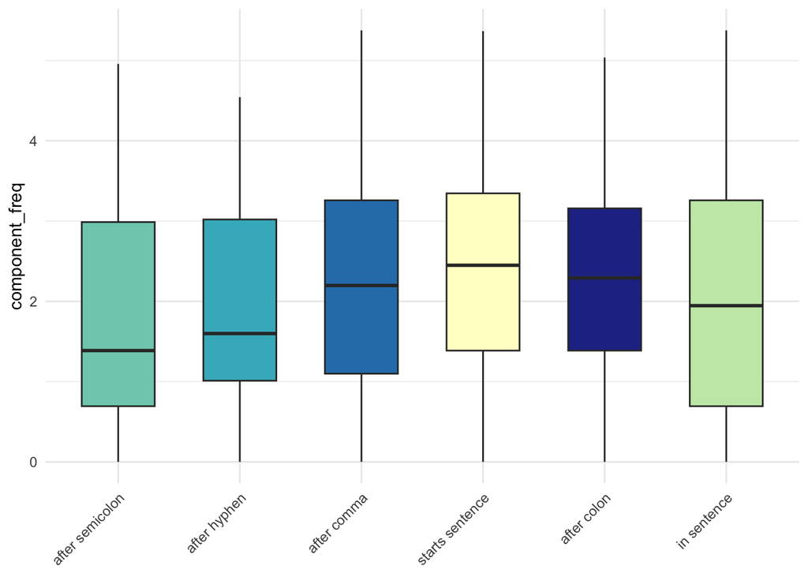

```r
onoms_long |>
  filter(!is.na(pre_isolation)) |>
  filter(pre_isolation != 'in brackets') |>
  ggplot(aes(x = reorder(pre_isolation, component_freq), y = component_freq,
             fill = pre_isolation)) +
  scale_fill_brewer(direction = -1,
                    palette = 'YlGnBu') +
  geom_boxplot(width = 0.6) +
  xlab(NULL) +
  theme_minimal() +
  theme(axis.text.x = element_text(angle = 45, hjust = 1),
        legend.position = 'none')
```

```r
# Save:

ggsave('../figures/component_freq_by_sentence_position.pdf',
       width = 4.5, height = 4)
```

Don’t see anything in here.

# 8 Word clouds

```r
# set.seed(42)
# wordcloud(word = frequent_adjs$Word, freq = frequent_adjs$n, min.freq = 12,
#           max.words = 120, random.order = FALSE, rot.per = 0.20,
#           colors = brewer.pal(8, 'Dark2'),
#           scale = c(2.5, 0.25))
```